# **Data-Driven Insights into Medication Errors Across Healthcare Settings**

### **S. Taylor**

**A healthcare-focused data analysis project emphasizing real-world data challenges, exploratory insight generation, and decision-oriented storytelling.**

## **Project Introduction**

This project analyzes real-world medication safety incident data from the National Reporting and Learning System (NRLS) in England and Wales to identify patterns in errors, reported harm, and contributing process factors across healthcare settings. Using incident-level data, the analysis examines where errors occur, which types are most common, and how they vary by workflow stage, location, and care setting. The project accounts for real-world challenges such as incomplete reporting and inconsistent categorical data, applying transparent data preparation techniques to ensure analytical rigor. Insights are intended to support patient safety, quality improvement, and risk prioritization.

## **Project Summary**

This project explores real-world healthcare data to uncover patterns and variations in medication errors. It transforms raw, imperfect incident data into actionable insights through systematic cleaning, exploratory analysis, and visualization, with a focus on operational and population-level considerations.

## **Project Objectives**

The objective of this project is to systematically analyze medication safety incident data to identify error patterns, evaluate clinical risk, and generate insights to guide patient safety and quality improvement.

### 1. Data Cleansing & Preparation

Preprocessed and validated the dataset by labeling all missing or blank values as `'Unknown'`, creating a complete and reliable foundation for downstream analysis.

### 2. Summary Statistics

Provides initial validation of incident counts, error types, medication processes, guideline involvement, and temporal coverage.

### 3. Medication Error Analysis Workflow

Covers the four main stages of analysis: Overview of Medication Error Patterns, Harm Severity Stratification, Drivers and Context of Medication Errors, and Spatial and Temporal Variation.

## **Setup**

**Data Source:**

- CSV of National Patient Safety Incident Data from the University of Bath [(`nrls_data_open.csv`)](https://researchdata.bath.ac.uk/1307/?utm_source=chatgpt.com)

**Tools & Libraries:**

- **Python:** `pandas`, `matplotlib`, `seaborn`, `sqlite3`
- **SQL:** SQLite3, `%sql` magic in Jupyter (`ipython-sql`)
- **Notebook:** Jupyter for interactive analysis and visualization
- **Utilities:** `csv`, `squarify` for table formatting and treemaps

**Setup & Installation:**  
Load the CSV into a Pandas DataFrame and write to a local SQLite database (`MEA.db`).

- Establish a SQLite connection to enable SQL-based transformations alongside Python analysis.

```python
%%capture
!pip install pandas
!pip install squarify
import csv, sqlite3, pandas as pd, matplotlib.pyplot as plt, seaborn as sns, matplotlib.cm as cm, squarify

con = sqlite3.connect("MEA.db")
cur = con.cursor()

%load_ext sql
%sql sqlite:///MEA.db
```

```python
colors = ["#becd6f", "#f1b31b", "#ecb792", "#ffb6ca", "#e98103", "#9b2c1b",
          "#a7b4bb", "#049280", "#8b830d", "#4c5421", "#e05330", "#ef9451",
          "#4f402e", "#04555a", "#386866", "#6e87a3"]
```

## **Data Overview**

### `incident_data_df` | [National Patient Safety Incident Data](https://researchdata.bath.ac.uk/1307/?utm_source=chatgpt.com)

| Column Name | Description |
| --- | --- |
| `incidentID` | Unique incident identification number |
| `CareSettingofOccurrence` | Care setting in which the incident occurred |
| `Locationlvl1` | Higher-level (less detailed) location of the incident |
| `Locationlvl2` | Lower-level (more detailed) location of the incident |
| `Guidelinecausecategory` | Detailed coding of deviations from expected practice; hierarchical codes indicating task step and error mode. Three-character codes: first = task step (1–3), second = error mode (**A** or **R**), thir… |
| `HighLevelCause` | Primary coding of deviations at a higher (less detailed) level. **1–3**: Deviation from hierarchical task analysis steps 1–3; **4**: Incident not describing a deviation |
| `Guidelineinvolved1` / `Guidelinesinvolved2` / `Guidelinesinvolved3` | Primary / secondary / tertiary clinical guideline involved. Codes: **BNF** = British National Formulary; **Medusa/IMG** = NHS Injectable Medicines Guide; **SPC** = Summary of Product Characteristics; … |
| `DoublecheckGuidelinecausecategory` | Secondary coding of deviations for inter-rater reliability assessment |
| `SpecialtyLvl1` | Higher-level clinical specialty of the incident |
| `SpecialtyLvl2` | Lower-level clinical specialty of the incident |
| `ReportedDegreeofHarm` | Reported patient harm. **No harm**: Patient not harmed; **Low**: Minor harm; **Moderate**: Short-term harm requiring treatment; **Severe**: Permanent/long-term harm; **Death**: Death caused by the inc… |
| `MedProcess` | Stage of medication use process at which the incident occurred |
| `MedErrorCategory` | Type of medication error associated with the incident |
| `ApprovedNameDrug1` | Generic name of first drug involved |
| `ApprovedNameDrug2` | Generic name of second drug involved |
| `ProprietaryNameDrug2` | Brand name of second drug involved |
| `ProprietaryNameDrug1` | Brand name of first drug involved |
| `RouteDrug1` | Route of administration of a drug involved |
| `Year_of_Occurrence` | Calendar year in which in incident occurred |
| `Term1` | Full NRLS search term matched in a free-text variable that led to inclusion of the incident in the study |
| `Term1_In` | Free-text variable in which `Term1` was matched |

```python
%%capture
incident_data_df = pd.read_csv('nrls_data_open.csv')
```

## **Data Cleansing & Preparation**

The goal of data cleansing is to produce a reliable and analytically consistent medication error dataset while preserving realistic reporting characteristics. Missing and blank values were explicitly labeled as `'Unknown'` rather than removed, keeping the dataset complete and transparent for downstream analysis.

### Key Fixes Applied

- **Guideline Involvement (`Guidelineinvolved1`)** – 2,451 missing entries imputed as `'Unknown'`.
- **Generic Drug Names**
  - `ApprovedNameDrug1`: 487 missing → `'Unknown'`
  - `ApprovedNameDrug2`: 5,457 missing → `'Unknown'`
- **Proprietary Drug Names**
  - `ProprietaryNameDrug1`: 5,593 missing → `'Unknown'`
  - `ProprietaryNameDrug2`: 5,704 missing → `'Unknown'`
- **Other Columns Cleaned**
  - `incidentID` (1), `Locationlvl2` (105), `Guidelinesinvolved2` (5,478), `Guidelinesinvolved3` (5,693),  
    `DoublecheckGuidelinecausecategory` (5,206), `RouteDrug1` (4,122), `SpecialtyLvl1` (60)
  - `SpecialtyLvl2` (1,241) → blanks replaced with `'Unknown'`.

**Outcome:** After these operations, the dataset contains **no missing or blank values**, resulting in `incident_data_clean_df` — a robust foundation for analyzing error patterns, contributing factors, and trends. The cleaned dataset was loaded into SQLite (`IncidentData`) for SQL and Python-based analysis.

```python
missing_data = (incident_data_df.isna() | (incident_data_df == ' ')).sum()
missing_data[missing_data > 0]
```

```
incidentID                              1
Locationlvl2                          105
Guidelineinvolved1                   2451
Guidelinesinvolved2                  5478
Guidelinesinvolved3                  5693
DoublecheckGuidelinecausecategory    5206
SpecialtyLvl1                          60
SpecialtyLvl2                        1241
ApprovedNameDrug1                     487
ApprovedNameDrug2                    5457
ProprietaryNameDrug2                 5704
ProprietaryNameDrug1                 5593
RouteDrug1                           4122
dtype: int64
```

```python
incident_data_clean_df = incident_data_df.copy()

# Columns where blanks (' ') should become 'Unknown'
blank_cols = [
    'incidentID', 'Guidelinesinvolved2', 'Guidelinesinvolved3', 'DoublecheckGuidelinecausecategory',
    'ApprovedNameDrug1', 'ApprovedNameDrug2', 'ProprietaryNameDrug1', 'ProprietaryNameDrug2',
    'RouteDrug1', 'SpecialtyLvl1', 'SpecialtyLvl2', 'Locationlvl2']

# Replace literal spaces with 'Unknown'
incident_data_clean_df[blank_cols] = incident_data_clean_df[blank_cols].replace(' ', 'Unknown')

# Columns where NULL/NaN should become 'Unknown'
null_cols = [
    'Guidelineinvolved1', 'ApprovedNameDrug1',
    'ApprovedNameDrug2', 'ProprietaryNameDrug1']

# Fill NaNs with 'Unknown'
incident_data_clean_df[null_cols] = incident_data_clean_df[null_cols].fillna('Unknown')
```

```python
missing_data_clean = (incident_data_clean_df.isna() | (incident_data_clean_df == ' ')).sum()
missing_data_clean[missing_data_clean > 0]
```

```
Series([], dtype: int64)
```

```python
%%capture
incident_data_clean_df.to_sql(
    "IncidentData",
    con,
    if_exists="replace",
    index=False)
```

## **Summary Statistics & Initial Validation**

This step provides an initial quantitative overview of the medication error dataset to validate data quality and identify major patterns. Key operational metrics are summarized to highlight the distribution of harm, error types, process stages, guideline involvement, and temporal trends. These metrics set the stage for deeper analyses of contributing factors, workflow vulnerabilities, and intervention impact.

**Key Metrics:**

- **ReportedDegreeofHarm:** Mostly No Harm (4,368); severe/fatal events are rare.
- **MedErrorCategory:** Top errors = Other, Wrong/unclear dose, Omitted medicine.
- **MedProcess:** Most errors occur during Administration or Prescribing.
- **Guidelinesinvolved:** Majority Unknown; local/national guidelines less frequent.
- **Year_of_Occurrence:** Peaks around 2019; early years sparse.

**Analytic Rationale:**

- `MedErrorCategory` for headline analysis: low-dimensional, operationally interpretable, allows reliable comparison across units, locations, and time.
- `Guidelinecausecategory` for context: identifies process and cognitive contributors, explaining why errors occurred without complicating top-level metrics.

### `ReportedDegreeofHarm`

Summarizes the distribution of patient harm, from no harm (4,368 incidents) to death (23 incidents), providing an initial view of clinical risk.

```python
%%sql
SELECT
    ReportedDegreeofHarm,
    COUNT(*) AS Occurrence_Count
FROM IncidentData
GROUP BY ReportedDegreeofHarm
ORDER BY Occurrence_Count DESC;
```

```
 * sqlite:///MEA.db
Done.
```

| ReportedDegreeofHarm | Occurrence_Count |
| --- | --- |
| No Harm | 4368 |
| Low | 732 |
| Moderate | 516 |
| Severe | 69 |
| Death | 23 |

### `MedErrorCategory`

Counts of incidents by `MedErrorCategory` to identify the most common types of medication errors across the dataset, providing a baseline for prioritizing safety interventions.

```python
%%sql
SELECT
    MedErrorCategory,
    COUNT(*) AS Occurrence_Count
FROM IncidentData
GROUP BY MedErrorCategory
ORDER BY Occurrence_Count DESC
LIMIT 5;
```

```
 * sqlite:///MEA.db
Done.
```

| MedErrorCategory | Occurrence_Count |
| --- | --- |
| Other | 1153 |
| Wrong / unclear dose or strength | 1127 |
| Omitted medicine / ingredient | 715 |
| Wrong frequency | 492 |
| Wrong quantity | 393 |

Crossed with `ReportedDegreeofHarm` to identify which error categories are associated with low, moderate, or high patient harm, highlighting areas of clinical risk and prioritization.

```python
%%sql
SELECT
    MedErrorCategory,
    ReportedDegreeofHarm,
    COUNT(*) AS Occurrence_Count
FROM IncidentData
GROUP BY MedErrorCategory, ReportedDegreeofHarm
HAVING Occurrence_Count >= 20 AND ReportedDegreeofHarm != "No Harm"
ORDER BY Occurrence_Count DESC
LIMIT 10;
```

```
 * sqlite:///MEA.db
Done.
```

| MedErrorCategory | ReportedDegreeofHarm | Occurrence_Count |
| --- | --- | --- |
| Other | Low | 137 |
| Wrong / unclear dose or strength | Low | 114 |
| Omitted medicine / ingredient | Low | 111 |
| Wrong / unclear dose or strength | Moderate | 94 |
| Other | Moderate | 91 |
| Omitted medicine / ingredient | Moderate | 87 |
| Wrong frequency | Low | 59 |
| Adverse drug reaction (when used as intended) | Moderate | 58 |
| Adverse drug reaction (when used as intended) | Low | 57 |
| Wrong drug / medicine | Low | 47 |

Crossed with `MedProcess` to identify which medication error categories occur at each stage of the medication use process, highlighting workflow vulnerabilities and opportunities for process-level interventions.

```python
%%sql
SELECT
    MedErrorCategory,
    MedProcess,
    COUNT(*) AS Occurrence_Count
FROM IncidentData
GROUP BY MedErrorCategory, MedProcess
ORDER BY Occurrence_Count DESC
LIMIT 5;
```

```
 * sqlite:///MEA.db
Done.
```

| MedErrorCategory | MedProcess | Occurrence_Count |
| --- | --- | --- |
| Wrong / unclear dose or strength | Prescribing | 706 |
| Other | Administration / supply of a medicine from a clinical area | 416 |
| Omitted medicine / ingredient | Administration / supply of a medicine from a clinical area | 385 |
| Wrong / unclear dose or strength | Administration / supply of a medicine from a clinical area | 285 |
| Other | Prescribing | 279 |

### `MedProcess`

Summarizes the overall frequency of incidents by `MedProcess`, highlighting the stages of medication use most commonly involved in errors to inform workflow-focused safety improvements.

```python
%%sql
SELECT
    MedProcess,
    COUNT(*) AS Occurrence_Count
FROM IncidentData
GROUP BY MedProcess
ORDER BY Occurrence_Count DESC;
```

```
 * sqlite:///MEA.db
Done.
```

| MedProcess | Occurrence_Count |
| --- | --- |
| Administration / supply of a medicine from a clinical area | 2399 |
| Prescribing | 2022 |
| Other | 425 |
| Preparation of medicines in all locations / dispensing in a pharmacy | 366 |
| Monitoring / follow-up of medicine use | 362 |
| Advice | 119 |
| Supply or use of over-the-counter (OTC) medicine | 15 |

### `GuidelinesinvolvedAll`

Aggregates guideline involvement across `Guidelineinvolved1`, `Guidelinesinvolved2`, and `Guidelinesinvolved3` to quantify which clinical guidelines are most frequently associated with reported incidents, supporting evaluation of guideline adherence and coverage gaps.

```python
%%sql
SELECT Guideline, COUNT(*) AS IncidentCount
FROM (
    SELECT Guidelineinvolved1 AS Guideline FROM IncidentData
    UNION ALL
    SELECT Guidelinesinvolved2 FROM IncidentData
    UNION ALL
    SELECT Guidelinesinvolved3 FROM IncidentData
) AS GuidelinesinvolvedAll
GROUP BY Guideline
ORDER BY IncidentCount DESC;
```

```
 * sqlite:///MEA.db
Done.
```

| Guideline | IncidentCount |
| --- | --- |
| Unknown | 13964 |
| Local guideline | 2016 |
| Medusa/IMG | 336 |
| Other | 290 |
| BNF | 271 |
| NICE guideline | 124 |
| SPC | 116 |
| CKS | 7 |

### `Year_of_Occurrence`

Summarizes the temporal distribution of incidents by `Year_of_Occurrence`, providing insight into reporting patterns over time and supporting trend analysis for patient safety monitoring and intervention assessment.

```python
%%sql
SELECT
    Year_of_Occurrence,
    COUNT(*) AS IncidentCount
FROM IncidentData
GROUP BY Year_of_Occurrence
ORDER BY Year_of_Occurrence;
```

```
 * sqlite:///MEA.db
Done.
```

| Year_of_Occurrence | IncidentCount |
| --- | --- |
| 1951 | 1 |
| 2008 | 1 |
| 2012 | 1 |
| 2014 | 7 |
| 2015 | 127 |
| 2016 | 849 |
| 2017 | 890 |
| 2018 | 1010 |
| 2019 | 1037 |
| 2020 | 982 |
| 2021 | 803 |

Provides key temporal metrics including earliest, latest, average, median, and most frequently reported year, offering a concise overview of incident timing and central tendencies for longitudinal analysis.

```python
%%sql
SELECT
    MIN(Year_of_Occurrence) AS Earliest_Year_Recorded,
    ROUND(AVG(Year_of_Occurrence), 2) AS Avg_Year_By_Occurrence_Count,
    (
        SELECT Year_of_Occurrence
        FROM IncidentData
        GROUP BY Year_of_Occurrence
        ORDER BY COUNT(*) DESC, Year_of_Occurrence ASC
        LIMIT 1
    ) AS Year_Appearing_Most,
    (
        SELECT AVG(Year_of_Occurrence)
        FROM (SELECT Year_of_Occurrence
              FROM IncidentData
              ORDER BY Year_of_Occurrence
              LIMIT 2 - (SELECT COUNT(*) FROM IncidentData) % 2
              OFFSET (SELECT (COUNT(*) - 1) / 2
                      FROM IncidentData))
    ) AS Median_Year_By_Occurrence_Count,
    MAX(Year_of_Occurrence) AS Latest_Year_Recorded
FROM IncidentData;
```

```
 * sqlite:///MEA.db
Done.
```

| Earliest_Year_Recorded | Avg_Year_By_Occurrence_Count | Year_Appearing_Most | Median_Year_By_Occurrence_Count | Latest_Year_Recorded |
| --- | --- | --- | --- | --- |
| 1951 | 2018.41 | 2019 | 2018.0 | 2021 |

## **Medication Error Analysis Workflow**

Covers the four main stages of analysis: Overview of Medication Error Patterns, Harm Severity Stratification, Drivers and Context of Medication Errors, and Spatial and Temporal Variation.

1. **Overview of Medication Error Patterns**
   - Understanding where medication errors cluster (`MedErrorCategory`, `ApprovedNameDrug1`, `ApprovedNameDrug2`) helps prioritize interventions and reduce patient risk.
   - Including the 10 most frequent error types shows which errors are most common, guiding attention to high-volume issues like wrong dose or omitted medicine.
   - Tracking errors by the most frequently implicated drugs identifies medications with repeated incidents, informing targeted education or process adjustments.
1. **Harm Severity Stratification**
   - Breaking down errors by `ReportedDegreeofHarm` reveals not just how often errors occur, but how serious they are, helping teams prioritize interventions based on potential patient impact.
   - Including all harm levels shows that most errors (e.g., wrong dose, omitted medicine) are low- or no-harm, highlighting frequent, low-risk issues that still affect workflow.
   - Excluding 'No Harm' focuses attention on clinically significant errors, showing which error types (e.g., wrong dose, adverse drug reactions) contribute most to patient risk and need targeted prevention.
1. **Drivers and Context of Medication Errors**
   - Analyzing `Guidelinecausecategory` highlights underlying process and cognitive contributors, showing which guideline-related causes drive the most incidents.
   - Contextualizing error types within guideline causes shows which combinations (e.g., wrong dose under specific guideline causes) create high-risk scenarios.
   - Evaluating `MedProcess` identifies stages in the medication use workflow most prone to errors, highlighting opportunities for process improvement.
   - Mapping errors to `GuidelinesinvolvedAll` clarifies which clinical guidelines are most frequently implicated, helping prioritize guideline review or staff training.
1. **Spatial and Temporal Variation**
   - Examining error trends over time (`Year_of_Occurrence`) identifies periods of increased incidents and sustained problem areas, guiding time-based interventions.
   - Stratifying by harm level over time shows that high-severity events remain consistent, informing risk-based safety strategies.
   - Tracking errors by category over time identifies persistent problem areas, signaling where sustained attention is needed.
   - Comparing error distributions across `CareSettingofOccurrence`, `Locationlvl1`, and `Locationlvl2` highlights hotspots in hospitals, inpatient areas, and other care settings, guiding spatial targeting of interventions.

### 1. Overview of Medication Error Patterns

Understanding where medication errors cluster helps prioritize interventions and reduce patient risk.

Understanding where medication errors cluster by `MedErrorCategory`, `ApprovedNameDrug1`, and `ApprovedNameDrug2` highlights which error types and medications drive the most incidents, so teams can target improvements and reduce patient risk.

- Dose, strength, and omission errors drive the highest incident counts, showing where processes need the most attention.
- Specific medications are repeatedly involved in errors, highlighting high-risk drugs for monitoring and staff focus.
- Many errors involve unidentified drugs, signaling gaps in documentation that could compromise patient safety.

#### Distribution of Medication Errors Across 10 Most Frequent Categories | `MedErrorCategory`

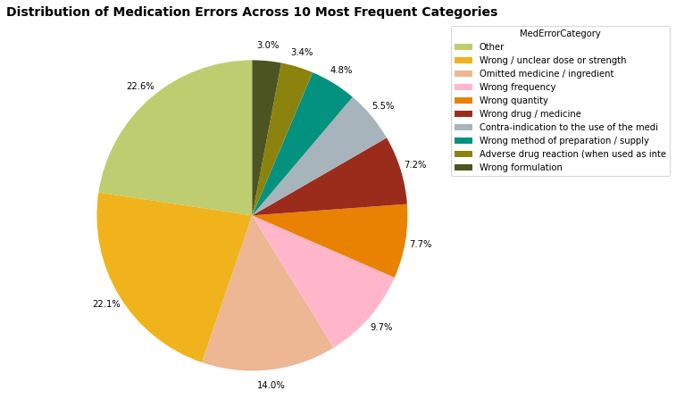

```python
mec_errors = pd.read_sql("""
SELECT
    MedErrorCategory,
    COUNT(*) AS IncidentCount
FROM IncidentData
GROUP BY MedErrorCategory
ORDER BY IncidentCount DESC
LIMIT 10;
""", con)

plt.figure(figsize=(8, 8))
patches, _, autotexts = plt.pie(
    mec_errors['IncidentCount'],
    labels=None,
    autopct='%1.1f%%',
    startangle=90,
    pctdistance=1.1,
    colors=colors
)
plt.legend(patches, mec_errors['MedErrorCategory'].str[:40], title="MedErrorCategory", bbox_to_anchor=(1, 1))
plt.title("Distribution of Medication Errors Across 10 Most Frequent Categories", fontsize=14, fontweight='bold')
plt.show()
```

#### Distribution of Medication Errors by Incident Count | `ApprovedNameDrug1`

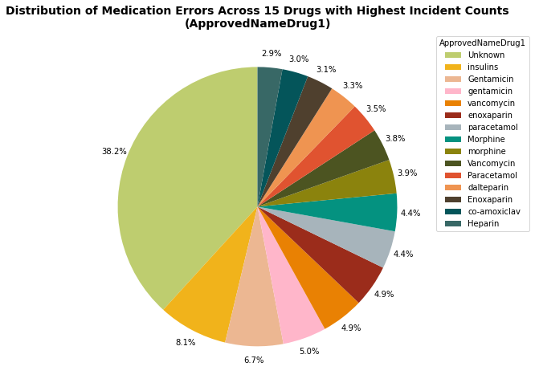

```python
drug1_errors = pd.read_sql("""
SELECT
    ApprovedNameDrug1,
    COUNT(*) AS IncidentCount
FROM IncidentData
GROUP BY ApprovedNameDrug1
HAVING ApprovedNameDrug1 != 'No Drug Given'
ORDER BY IncidentCount DESC
LIMIT 15;
""", con)

plt.figure(figsize=(8, 8))
patches, _, autotexts = plt.pie(
    drug1_errors['IncidentCount'],
    labels=None,
    autopct='%1.1f%%',
    startangle=90,
    pctdistance=1.1,
    colors=colors
)
plt.legend(patches, drug1_errors['ApprovedNameDrug1'], title="ApprovedNameDrug1", bbox_to_anchor=(1, 1))
plt.title("Distribution of Medication Errors Across 15 Drugs with Highest Incident Counts\n(ApprovedNameDrug1)", fontsize=14, fontweight='bold')
plt.show()
```

#### Distribution of Medication Errors by Incident Count | `ApprovedNameDrug2`

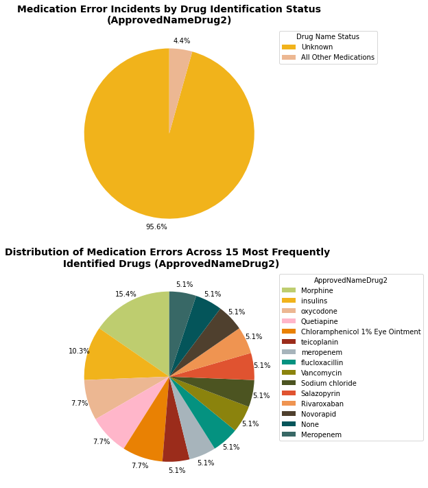

```python
drug2_errors_all = pd.read_sql("""
SELECT
    CASE
        WHEN ApprovedNameDrug2 = 'Unknown' THEN 'Unknown'
        ELSE 'All Other Medications'
    END AS Drug_Name_Status,
    COUNT(*) AS IncidentCount
FROM IncidentData
GROUP BY Drug_Name_Status
HAVING ApprovedNameDrug2 != 'No Drug Given'
ORDER BY IncidentCount DESC;
""", con)

drug2_errors = pd.read_sql(f"""
SELECT
    ApprovedNameDrug2,
    COUNT(*) AS IncidentCount
FROM IncidentData
GROUP BY ApprovedNameDrug2
HAVING ApprovedNameDrug2 != 'Unknown'
ORDER BY IncidentCount DESC
LIMIT 15;
""", con)

# --- Create vertical subplots ---
fig, axes = plt.subplots(2, 1, figsize=(8, 10))

patches, _, autotexts = axes[0].pie(
    drug2_errors_all['IncidentCount'],
    labels=None,
    autopct='%1.1f%%',
    startangle=90,
    pctdistance=1.1,
    colors=colors[1:]
)
axes[0].legend(patches, drug2_errors_all['Drug_Name_Status'], title="Drug Name Status", bbox_to_anchor=(1, 1))
axes[0].set_title("Medication Error Incidents by Drug Identification Status\n(ApprovedNameDrug2)", fontsize=14, fontweight='bold')

# Locationlvl2 pie
patches, _, autotexts = axes[1].pie(
    drug2_errors['IncidentCount'],
    labels=None,           # remove labels from slices
    autopct='%1.1f%%',     # percentages inside slices
    startangle=90,
    pctdistance=1.1,
    colors=colors
)
axes[1].legend(patches, drug2_errors['ApprovedNameDrug2'], title="ApprovedNameDrug2", bbox_to_anchor=(1, 1))
axes[1].set_title("Distribution of Medication Errors Across 15 Most Frequently \n Identified Drugs (ApprovedNameDrug2)", fontsize=14, fontweight='bold')

plt.tight_layout()
plt.show()
```

### 2. Harm Severity Stratification

Breaking down medication errors by `ReportedDegreeofHarm` reveals not just how often errors occur, but how serious they are, helping teams prioritize interventions based on potential patient impact.

- Including **all harm levels** shows that most errors (e.g., wrong dose, omitted medicine) are low- or no-harm, highlighting frequent, low-risk issues that still affect workflow.
- Excluding **'No Harm'** focuses attention on clinically significant errors, showing which error types (e.g., wrong dose, adverse drug reactions) contribute most to patient risk and need targeted prevention.

#### Medication Errors by Type Across Harm Levels | `ReportedDegreeofHarm` and `MedErrorCategory`

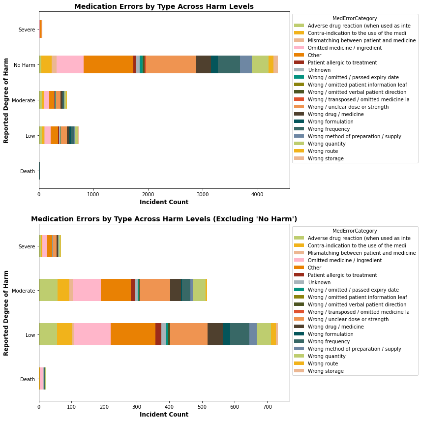

```python
df_harm_all = pd.read_sql("""
SELECT
    ReportedDegreeofHarm,
    MedErrorCategory,
    COUNT(*) AS IncidentCount
FROM IncidentData
GROUP BY ReportedDegreeofHarm, MedErrorCategory
ORDER BY IncidentCount DESC;
""", con)

df_harm = pd.read_sql("""
SELECT
    ReportedDegreeofHarm,
    MedErrorCategory,
    COUNT(*) AS IncidentCount
FROM IncidentData
GROUP BY ReportedDegreeofHarm, MedErrorCategory
HAVING ReportedDegreeofHarm != 'No Harm'
ORDER BY IncidentCount DESC;
""", con)

df_harm_pivot = df_harm.pivot_table(
    index='ReportedDegreeofHarm',
    columns='MedErrorCategory',
    values='IncidentCount',
    fill_value=0
)

colors_list_harm = colors[:len(df_harm_pivot.columns)]

df_harm_all_pivot = df_harm_all.pivot_table(
    index='ReportedDegreeofHarm',
    columns='MedErrorCategory',
    values='IncidentCount',
    fill_value=0
)

colors_list_all = colors[:len(df_harm_all_pivot.columns)]

# --- Create vertical subplots ---
fig, axes = plt.subplots(2, 1, figsize=(12, 12))

# All Harm Levels (including 'No Harm')
df_harm_all_pivot.plot(
    kind='barh',
    stacked=True,
    ax=axes[0],
    color=colors_list_all
)
axes[0].set_xlabel("Incident Count", fontsize=12, fontweight='bold')
axes[0].set_ylabel("Reported Degree of Harm", fontsize=12, fontweight='bold')
axes[0].set_title("Medication Errors by Type Across Harm Levels", fontsize=14, fontweight='bold')
axes[0].legend([str(c)[:40] for c in df_harm_all_pivot.columns], title="MedErrorCategory", bbox_to_anchor=(1, 1))

# Harm Level
df_harm_pivot.plot(
    kind='barh',
    stacked=True,
    ax=axes[1],
    color=colors_list_harm
)
axes[1].set_xlabel("Incident Count", fontsize=12, fontweight='bold')
axes[1].set_ylabel("Reported Degree of Harm", fontsize=12, fontweight='bold')
axes[1].set_title("Medication Errors by Type Across Harm Levels (Excluding 'No Harm')", fontsize=14, fontweight='bold')
axes[1].legend([str(c)[:40] for c in df_harm_pivot.columns], title="MedErrorCategory", bbox_to_anchor=(1, 1))

plt.tight_layout()
fig.subplots_adjust(hspace=0.2)
plt.show()
```

### 3. Drivers and Context of Medication Errors

Analyzing medication errors by `Guidelinecausecategory`, `MedErrorCategory`, `MedProcess`, and `GuidelinesinvolvedAll` reveals the underlying drivers and context of errors, helping teams prioritize interventions based on systemic risk and workflow vulnerabilities.

#### Distribution of Medication Errors by Guideline Cause Category | `Guidelinecausecategory`

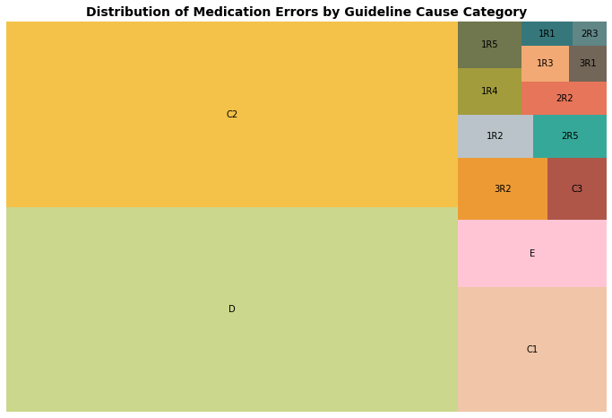

```python
df_guideline = pd.read_sql("""
SELECT
    Guidelinecausecategory,
    COUNT(*) AS IncidentCount
FROM IncidentData
GROUP BY Guidelinecausecategory
ORDER BY IncidentCount DESC
LIMIT 15;
""", con)

plt.figure(figsize=(12, 8))
squarify.plot(
    sizes=df_guideline['IncidentCount'],
    label=df_guideline['Guidelinecausecategory'],
    alpha=0.8,
    color=colors[:len(df_guideline)]
)

plt.title("Distribution of Medication Errors by Guideline Cause Category", fontsize=14, fontweight='bold')
plt.axis('off')
plt.show()
```

#### Medication Errors by Guideline Cause Category with Error Type Context | `Guidelinecausecategory` and `MedErrorCategory`

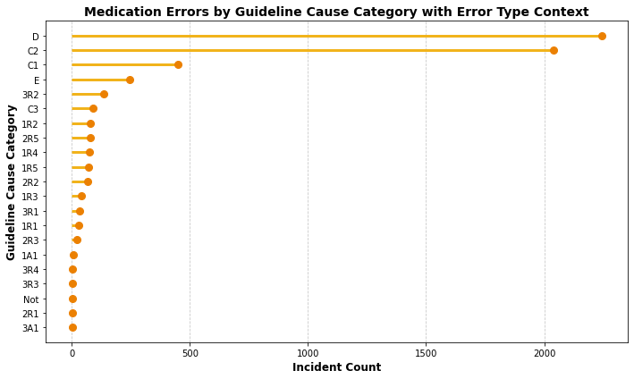

```python
df_guideline_nested = pd.read_sql("""
SELECT
    Guidelinecausecategory,
    MedErrorCategory,
    COUNT(*) AS IncidentCount
FROM IncidentData
GROUP BY Guidelinecausecategory, MedErrorCategory
ORDER BY IncidentCount DESC;
""", con)

# --- Aggregate by Guidelinecausecategory for lollipop heights ---
df_guideline_agg = df_guideline_nested.groupby('Guidelinecausecategory')['IncidentCount'].sum().reset_index()

# Sort for plotting
df_guideline_agg = df_guideline_agg.sort_values('IncidentCount')

# --- Lollipop / Dot Plot ---
plt.figure(figsize=(10, 6))
plt.hlines(y=df_guideline_agg['Guidelinecausecategory'], xmin=0, xmax=df_guideline_agg['IncidentCount'], color='#f1b31b', linewidth=3)
plt.plot(df_guideline_agg['IncidentCount'], df_guideline_agg['Guidelinecausecategory'], "o", color='#eb8002', markersize=8)

plt.xlabel("Incident Count", fontsize=12, fontweight='bold')
plt.ylabel("Guideline Cause Category", fontsize=12, fontweight='bold')
plt.title("Medication Errors by Guideline Cause Category with Error Type Context", fontsize=14, fontweight='bold')
plt.grid(axis='x', linestyle='--', alpha=0.7)
plt.tight_layout()
plt.show()
```

#### Distribution of Medication Errors Across Medication Use Process Steps | `MedProcess`

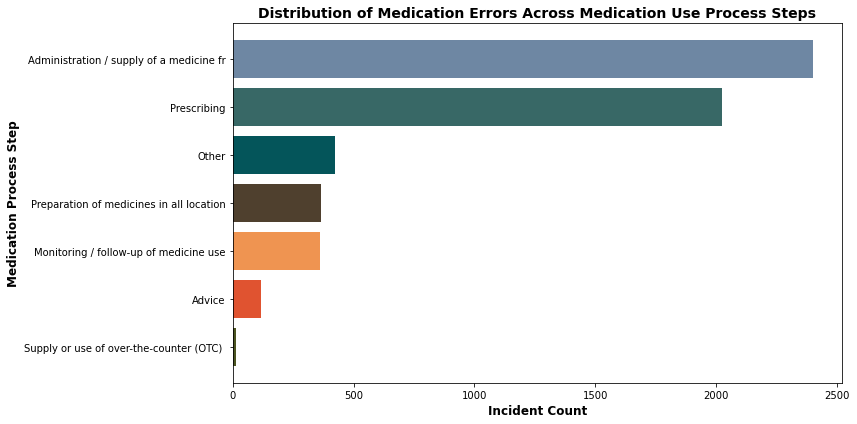

```python
process_errors = pd.read_sql("""
SELECT
    MedProcess,
    COUNT(*) AS IncidentCount
FROM IncidentData
GROUP BY MedProcess
ORDER BY IncidentCount DESC;
""", con)

plt.figure(figsize=(12, 6))
process_errors_sorted = process_errors.sort_values('IncidentCount')
plt.barh(process_errors_sorted['MedProcess'].str[:40], process_errors_sorted['IncidentCount'], color=colors[-7:])
plt.xlabel("Incident Count", fontsize=12, fontweight='bold')
plt.ylabel("Medication Process Step", fontsize=12, fontweight='bold')
plt.title("Distribution of Medication Errors Across Medication Use Process Steps", fontsize=14, fontweight='bold')
plt.tight_layout()
plt.show()
```

#### Variation of Medication Errors Across Workflow Stages by Error Type | `MedProcess` and `MedErrorCategory`

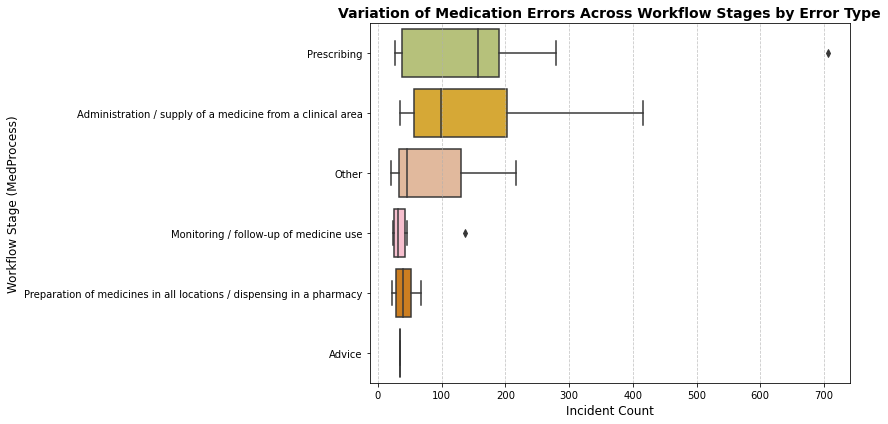

```python
df_workflow_detailed = pd.read_sql("""
SELECT
    MedProcess,
    MedErrorCategory,
    COUNT(*) AS IncidentCount
FROM IncidentData
GROUP BY MedProcess, MedErrorCategory
HAVING COUNT(*) >= 20
ORDER BY IncidentCount DESC;
""", con)

plt.figure(figsize=(12,6))
sns.boxplot(x='IncidentCount', y='MedProcess', data=df_workflow_detailed, orient='h', palette=colors)
plt.xlabel("Incident Count", fontsize=12)
plt.ylabel("Workflow Stage (MedProcess)", fontsize=12)
plt.title("Variation of Medication Errors Across Workflow Stages by Error Type", fontsize=14, fontweight='bold')
plt.grid(axis='x', linestyle='--', alpha=0.7)
plt.tight_layout()
plt.show()
```

#### Distribution of Medication Errors Across Clinical Guidelines | `Guidelineinvolved1`, `Guidelinesinvolved2`, and `Guidelinesinvolved3`

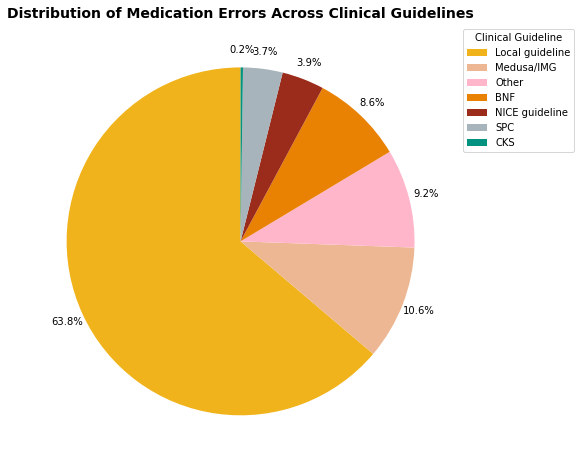

```python
guide_errors = pd.read_sql("""
WITH GuidelinesCombined AS (
    SELECT Guidelineinvolved1 AS Guideline FROM IncidentData
    UNION ALL
    SELECT Guidelinesinvolved2 FROM IncidentData
    UNION ALL
    SELECT Guidelinesinvolved3 FROM IncidentData
)
SELECT
    Guideline AS GuidelinesinvolvedAll,
    COUNT(*) AS IncidentCount
FROM GuidelinesCombined
GROUP BY Guideline
HAVING GuidelinesinvolvedAll != 'Unknown'
ORDER BY IncidentCount DESC;
""", con)

plt.figure(figsize=(8, 8))
patches, _, autotexts = plt.pie(
    guide_errors['IncidentCount'],
    labels=None,
    autopct='%1.1f%%',
    startangle=90,
    pctdistance=1.1,
    colors=colors[1:]
)
plt.legend(patches, guide_errors['GuidelinesinvolvedAll'], title="Clinical Guideline", bbox_to_anchor=(1, 1))
plt.title("Distribution of Medication Errors Across Clinical Guidelines", fontsize=14, fontweight='bold')
plt.show()
```

### 4. Spatial and Temporal Variation

Examining medication errors over time (`Year_of_Occurrence`) and across locations (`CareSettingofOccurrence`, `Locationlvl1`, `Locationlvl2`) highlights trends and hotspots, helping teams target interventions where and when errors are most likely to occur.

- Overall incidents have increased sharply since 2014, with peaks around 2018–2019, showing periods where workload or system changes may have contributed to errors.
- Stratifying by harm level shows that high-severity events remain relatively low, but still occur consistently each year, guiding risk-based safety efforts.
- Tracking errors by category over time identifies persistent problem areas, like wrong dose and omitted medicines, signaling areas for sustained attention.
- Errors are concentrated in acute/general hospitals and inpatient areas, indicating that these settings are high-priority targets for process improvements.
- Community, primary care, and outpatient settings account for smaller but significant numbers of incidents, showing that interventions should extend beyond hospitals.

#### Medication Error Incident Trends by Year | `Year_of_Occurrence`

```python
%%sql
SELECT
    Year_of_Occurrence,
    COUNT(*) AS IncidentCount
FROM IncidentData
GROUP BY Year_of_Occurrence
ORDER BY Year_of_Occurrence;
```

```
 * sqlite:///MEA.db
Done.
```

| Year_of_Occurrence | IncidentCount |
| --- | --- |
| 1951 | 1 |
| 2008 | 1 |
| 2012 | 1 |
| 2014 | 7 |
| 2015 | 127 |
| 2016 | 849 |
| 2017 | 890 |
| 2018 | 1010 |
| 2019 | 1037 |
| 2020 | 982 |
| 2021 | 803 |

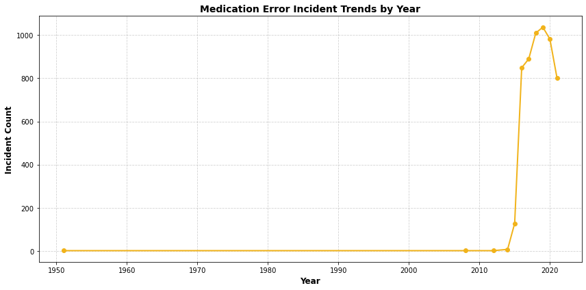

```python
df_year = pd.read_sql("""
SELECT
    Year_of_Occurrence,
    COUNT(*) AS IncidentCount
FROM IncidentData
GROUP BY Year_of_Occurrence
ORDER BY Year_of_Occurrence;
""", con)

plt.figure(figsize=(12,6))
plt.plot(df_year['Year_of_Occurrence'], df_year['IncidentCount'], marker='o', color='#f1b31b', linewidth=2)
plt.xlabel("Year", fontsize=12, fontweight='bold')
plt.ylabel("Incident Count", fontsize=12, fontweight='bold')
plt.title("Medication Error Incident Trends by Year", fontsize=14, fontweight='bold')
plt.grid(True, linestyle='--', alpha=0.6)
plt.tight_layout()
plt.show()
```

#### Medication Error Trends by Year and Reported Harm Severity | `Year_of_Occurrence` and `ReportedDegreeofHarm`

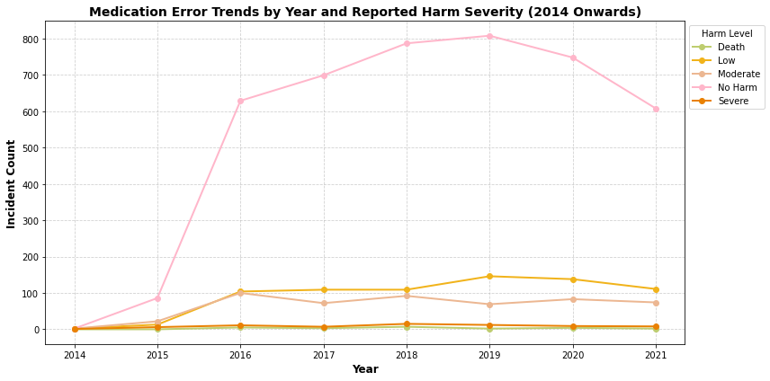

```python
df_year_harm = pd.read_sql("""
SELECT
    Year_of_Occurrence,
    ReportedDegreeofHarm,
    COUNT(*) AS IncidentCount
FROM IncidentData
GROUP BY Year_of_Occurrence, ReportedDegreeofHarm
HAVING Year_of_Occurrence >= 2014
ORDER BY Year_of_Occurrence;
""", con)

# Pivot for plotting
df_year_harm_pivot = df_year_harm.pivot(index='Year_of_Occurrence', columns='ReportedDegreeofHarm',
                                        values='IncidentCount').fillna(0)

# Plot
df_year_harm_pivot.plot(
    figsize=(12,6),
    marker='o',
    linewidth=2,
    color=colors[:len(df_year_harm_pivot.columns)]
)
plt.xlabel("Year", fontsize=12, fontweight='bold')
plt.ylabel("Incident Count", fontsize=12, fontweight='bold')
plt.title("Medication Error Trends by Year and Reported Harm Severity (2014 Onwards)", fontsize=14, fontweight='bold')
plt.grid(True, linestyle='--', alpha=0.6)
plt.legend(title="Harm Level", bbox_to_anchor=(1,1))
plt.tight_layout()
plt.show()
```

#### Trends in Medication Errors by Category | `Year_of_Occurrence` and `MedErrorCategory`

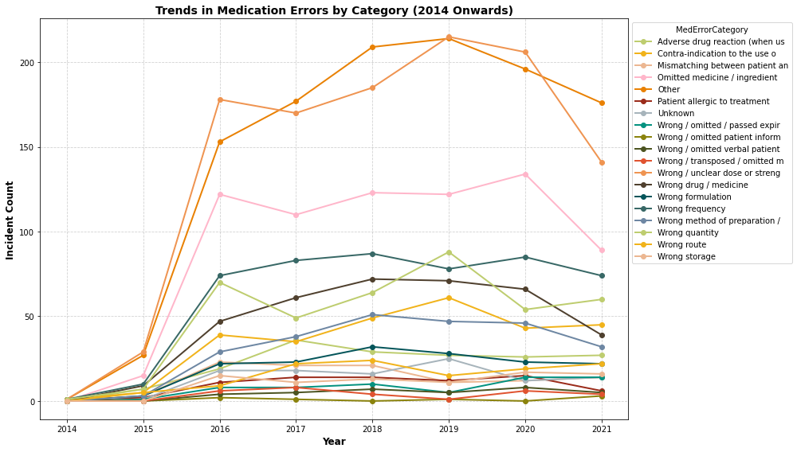

```python
df_year_error = pd.read_sql("""
SELECT
    Year_of_Occurrence,
    MedErrorCategory,
    COUNT(*) AS IncidentCount
FROM IncidentData
GROUP BY Year_of_Occurrence, MedErrorCategory
HAVING Year_of_Occurrence >= 2014
ORDER BY Year_of_Occurrence;
""", con)

# Pivot for plotting
df_year_error_pivot = df_year_error.pivot(
    index='Year_of_Occurrence',
    columns='MedErrorCategory',
    values='IncidentCount'
).fillna(0)

# Plot
df_year_error_pivot.plot(
    figsize=(14,8),
    marker='o',
    linewidth=2,
    color=colors[:len(df_year_error_pivot.columns)]
)
plt.xlabel("Year", fontsize=12, fontweight='bold')
plt.ylabel("Incident Count", fontsize=12, fontweight='bold')
plt.title("Trends in Medication Errors by Category (2014 Onwards)", fontsize=14, fontweight='bold')
plt.grid(True, linestyle='--', alpha=0.6)
plt.legend([str(c)[:30] for c in df_year_error_pivot.columns], title="MedErrorCategory", bbox_to_anchor=(1,1))
plt.tight_layout()
plt.show()
```

#### Medication Errors by Care Setting and Location | `CareSettingofOccurrence`, `Locationlvl1`, and `Locationlvl2`

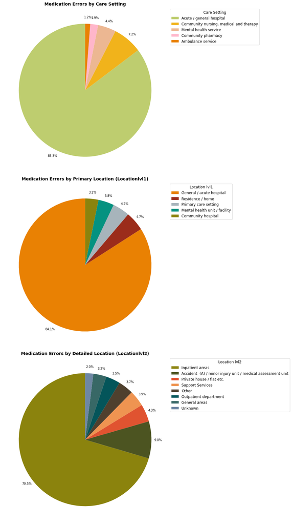

```python
df_care = pd.read_sql(f"""
SELECT
    CareSettingofOccurrence,
    COUNT(*) AS IncidentCount
FROM IncidentData
GROUP BY CareSettingofOccurrence
ORDER BY IncidentCount DESC
LIMIT 5;
""", con)

df_loc1 = pd.read_sql(f"""
SELECT
    Locationlvl1,
    COUNT(*) AS IncidentCount
FROM IncidentData
GROUP BY Locationlvl1
ORDER BY IncidentCount DESC
LIMIT 5;
""", con)

df_loc2 = pd.read_sql(f"""
SELECT
    Locationlvl2,
    COUNT(*) AS IncidentCount
FROM IncidentData
GROUP BY Locationlvl2
ORDER BY IncidentCount DESC
LIMIT 8;
""", con)

# --- Create vertical subplots ---
fig, axes = plt.subplots(3, 1, figsize=(12, 24))

# Care Setting pie
patches, _, autotexts = axes[0].pie(
    df_care['IncidentCount'],
    labels=None,
    autopct='%1.1f%%',
    startangle=90,
    pctdistance=1.1,
    colors=colors[0:]
)

axes[0].legend(patches, df_care['CareSettingofOccurrence'].str[:38], title="Care Setting",
               fontsize=12, title_fontsize=12, bbox_to_anchor=(1, 1))
axes[0].set_title("Medication Errors by Care Setting", fontsize=14, fontweight='bold')


# Locationlvl1 pie
patches, _, autotexts = axes[1].pie(
    df_loc1['IncidentCount'],
    labels=None,
    autopct='%1.1f%%',
    startangle=90,
    pctdistance=1.1,
    colors=colors[4:]
)
axes[1].legend(patches, df_loc1['Locationlvl1'], title="Location lvl1",
               fontsize=12, title_fontsize=12, bbox_to_anchor=(1, 1))
axes[1].set_title("Medication Errors by Primary Location (Locationlvl1)", fontsize=14, fontweight='bold')

# Locationlvl2 pie
patches, _, autotexts = axes[2].pie(
    df_loc2['IncidentCount'],
    labels=None,
    autopct='%1.1f%%',
    startangle=90,
    pctdistance=1.1,
    colors=colors[8:]
)
axes[2].legend(patches, df_loc2['Locationlvl2'], title="Location lvl2",
               fontsize=12, title_fontsize=12, bbox_to_anchor=(1, 1))
axes[2].set_title("Medication Errors by Detailed Location (Locationlvl2)", fontsize=14, fontweight='bold')

plt.tight_layout()
plt.show()
```

## **Conclusion**

This analysis of medication safety incidents delivers a detailed understanding of error patterns, contributing factors, and workflow vulnerabilities across healthcare settings. By examining error types, harm severity, process stages, guideline involvement, and spatial–temporal trends, the report generates actionable insights for patient safety and quality improvement.

Overall, these insights equip patient safety teams, clinical managers, and healthcare analysts to monitor risk, target interventions, and optimize workflows to reduce medication errors and improve care quality.

**Future Recommendations:**

- Focus **training, process redesign, and double-check protocols** on high-risk stages, particularly Administration and Prescribing.
- Target interventions for **high-risk medications** repeatedly involved in incidents.
- Standardize and reinforce clinical guideline adherence, especially for **local and widely used guidelines**.
- Implement **spatially focused safety strategies** in hospitals and inpatient units while maintaining coverage in outpatient and community care.
- Track trends over time to assess intervention effectiveness and anticipate periods of increased risk.
- Maintain ongoing **data quality and completeness efforts** to ensure reliable incident reporting and monitoring.